# Lab 5, Insurance Costs

Import Data

```python
import pandas as pd
df = pd.read_csv("Data/insurance_costs_1.csv")
```

Data Summary Run Libraries

```python
import pandas as pd
import numpy as np
from plotnine import *
```

Data Summary

```python
print("Dataset shape:", df.shape)
print("\nFirst few rows:")
print(df.head())

print("\nData types:")
print(df.dtypes)

print("\nSummary statistics:")
print(df.describe())

print("\nMissing values:")
print(df.isnull().sum())
```

```
Dataset shape: (431, 6)

First few rows:
   age     sex     bmi smoker     region      charges
0   19  female  27.900    yes  southwest  16884.92400
1   33    male  22.705     no  northwest  21984.47061
2   32    male  28.880     no  northwest   3866.85520
3   31  female  25.740     no  southeast   3756.62160
4   60  female  25.840     no  northwest  28923.13692

Data types:
age          int64
sex         object
bmi        float64
smoker      object
region      object
charges    float64
dtype: object

Summary statistics:
              age         bmi       charges
count  431.000000  431.000000    431.000000
mean    37.960557   30.768898  12297.098118
std     16.363909    6.111362  11876.527128
min     18.000000   15.960000   1131.506600
25%     22.000000   26.357500   2710.444575
50%     34.000000   30.590000   9866.304850
75%     55.000000   35.272500  14510.872600
max     64.000000   49.060000  55135.402090

Missing values:
age        0
sex        0
bmi        0
smoker     0
region     0
charges    0
dtype: int64
```

Fix Any Concerns

```python
df['sex'] = df['sex'].astype('category')
df['smoker'] = df['smoker'].astype('category')
df['region'] = df['region'].astype('category')

print("\nCleaned data types:")
print(df.dtypes)
```

```
Cleaned data types:
age           int64
sex        category
bmi         float64
smoker     category
region     category
charges     float64
dtype: object
```

Plot 1: Charges vs Age

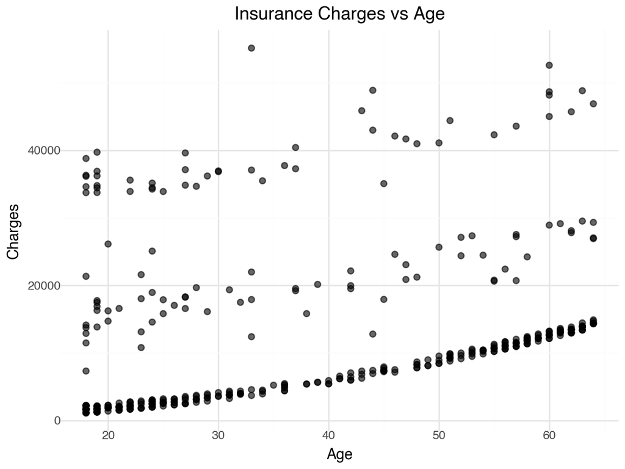

```python
plot1 = (ggplot(df, aes(x='age', y='charges')) +
         geom_point(alpha=0.6,color = "Black", size=2) +
         labs(title='Insurance Charges vs Age',
              x='Age',
              y='Charges') +
         theme_minimal())

plot1
```

There apears to be a correlation between charges increaseing as age increases, but since the change is not perfectly linear, we can assume there are other factors in play besides age.

Plot 2: Charges vs BMI

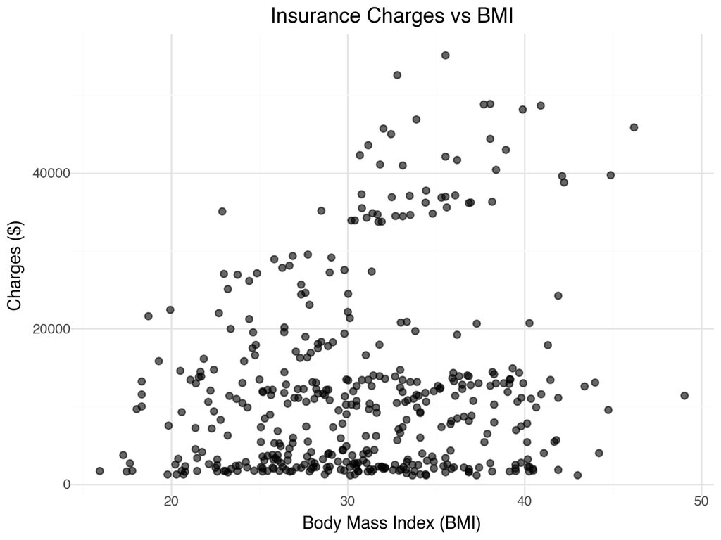

```python
plot2 = (ggplot(df, aes(x='bmi', y='charges')) +
         geom_point(alpha=0.6, color='Black', size=2) +
         labs(title='Insurance Charges vs BMI',
              x='Body Mass Index (BMI)',
              y='Charges ($)') +
         theme_minimal())
plot2
```

Body mass index does not appear to have much if any correlation to charges

Plot 3: Charges vs Smoker Status

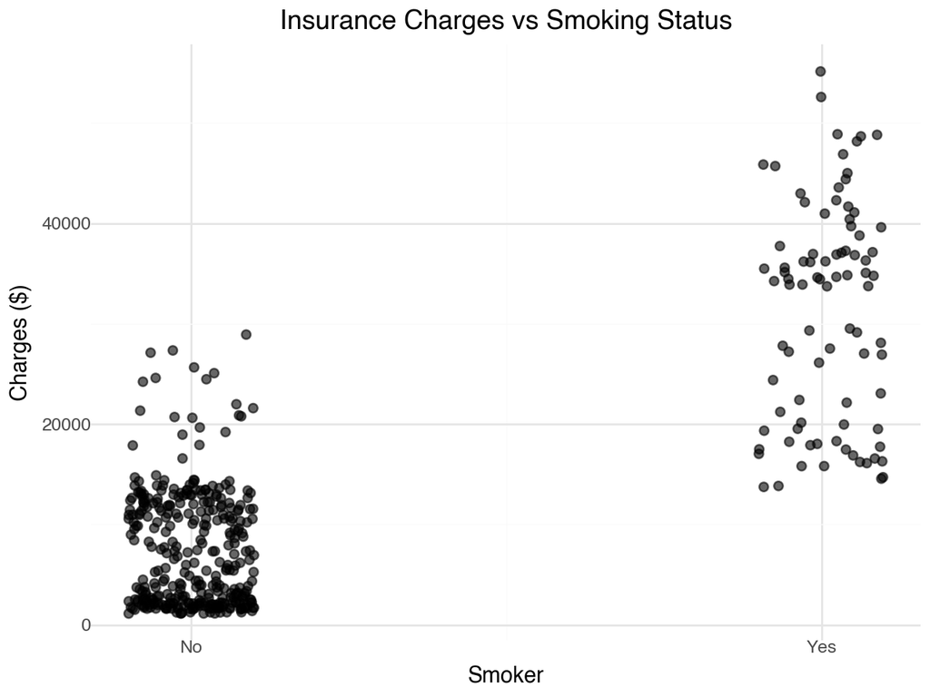

```python
df['smoker_numeric_plot'] = (df['smoker'] == 'yes').astype(int)

plot3 = (ggplot(df, aes(x='smoker_numeric_plot', y='charges')) +
         geom_jitter(alpha=0.6, color='Black', size=2, width=0.1) +
         scale_x_continuous(breaks=[0, 1], labels=['No', 'Yes']) +
         labs(title='Insurance Charges vs Smoking Status',
              x='Smoker',
              y='Charges ($)') +
         theme_minimal())
plot3
```

We can clearly see smokers get higher insurance charges on avg , but since some smokers have lower charges than non smokers, we can say there are other factors at play

Part 2

```python
import pandas as pd
import numpy as np
from sklearn.linear_model import LinearRegression
from sklearn.metrics import mean_squared_error, r2_score
```

Model with only age:

```python
X1 = df[['age']]
y = df['charges']

model1 = LinearRegression()
model1.fit(X1, y)

y_pred1 = model1.predict(X1)
mse1 = mean_squared_error(y, y_pred1)
r2_1 = r2_score(y, y_pred1)

print(f"Intercept: {model1.intercept_:.2f}")
print(f"Coefficient for age: {model1.coef_[0]:.2f}")
print(f"\nMSE: {mse1:.2f}")
print(f"R-squared: {r2_1:.4f}")
```

```
Intercept: 3611.76
Coefficient for age: 228.80

MSE: 126739267.91
R-squared: 0.0994
```

The intercept of 3611 can be interperted as the base charge of insruance assuming age is the only factor. Then for how old a person is tht number is multiplied by 228.8 to get the age premium. The MSe is extremely big and R squared very low, overall not a good model.

Model with age and sex

```python
df['sex_numeric'] = (df['sex'] == 'male').astype(int)

X2 = df[['age', 'sex_numeric']]
model2 = LinearRegression()
model2.fit(X2, y)

y_pred2 = model2.predict(X2)
mse2 = mean_squared_error(y, y_pred2)
r2_2 = r2_score(y, y_pred2)

print(f"Intercept: {model2.intercept_:.2f}")
print(f"Coefficient for age: {model2.coef_[0]:.2f}")
print(f"Coefficient for sex (male): {model2.coef_[1]:.2f}")
print(f"\nMSE: {mse2:.2f}")
print(f"R-squared: {r2_2:.4f}")
```

```
Intercept: 3315.33
Coefficient for age: 228.43
Coefficient for sex (male): 649.83

MSE: 126633939.68
R-squared: 0.1001
```

The intercept is similar to the last model as is the coeffience for age. The coefficent for sex(male) is 649.83 which can tell us males insurance charges are higher than females. MSE is still extremely large, but while the R squred is still low it improved in comprison to the last model.

Model with age and smoker, no sex

```python
df['smoker_numeric'] = (df['smoker'] == 'yes').astype(int)

X3 = df[['age', 'smoker_numeric']]
model3 = LinearRegression()
model3.fit(X3, y)

y_pred3 = model3.predict(X3)
mse3 = mean_squared_error(y, y_pred3)
r2_3 = r2_score(y, y_pred3)

print(f"Intercept: {model3.intercept_:.2f}")
print(f"Coefficient for age: {model3.coef_[0]:.2f}")
print(f"Coefficient for smoker (yes): {model3.coef_[1]:.2f}")
print(f"\nMSE: {mse3:.2f}")
print(f"R-squared: {r2_3:.4f}")
```

```
Intercept: -2166.85
Coefficient for age: 253.15
Coefficient for smoker (yes): 24048.87

MSE: 33719831.47
R-squared: 0.7604
```

The intercept now for smoker(yes) being in the model is -2166, age is 253 and smoker if yes is now 24048, this tells use the person being a smoker has a massive infulence on the insurance charge. MSE still very high, R squre now solid and has improved greatly from the last 2 models

Compare Model 2 and 3

```python
print("\nModel Q2 (age + sex):")
print(f"  MSE: {mse2:.2f}")
print(f"  R-squared: {r2_2:.4f}")

print("\nModel Q3 (age + smoker):")
print(f"  MSE: {mse3:.2f}")
print(f"  R-squared: {r2_3:.4f}")
```

```
Model Q2 (age + sex):
  MSE: 126633939.68
  R-squared: 0.1001

Model Q3 (age + smoker):
  MSE: 33719831.47
  R-squared: 0.7604
```

Model 3 fits the data much better with a much higher R squared and lower mse

Part 3

```python
import pandas as pd
import numpy as np
from sklearn.linear_model import LinearRegression
from sklearn.preprocessing import PolynomialFeatures
from sklearn.metrics import mean_squared_error, r2_score
from plotnine import *
```

Reference model part 2 q1

```python
y = df['charges']

X_ref = df[['age']]
model_ref = LinearRegression()
model_ref.fit(X_ref, y)
y_pred_ref = model_ref.predict(X_ref)
mse_ref = mean_squared_error(y, y_pred_ref)
r2_ref = r2_score(y, y_pred_ref)

print(f"  MSE: {mse_ref:.2f}")
print(f"  R-squared: {r2_ref:.4f}")
```

```
  MSE: 126739267.91
  R-squared: 0.0994
```

Model with age and bmi

```python
X1 = df[['age', 'bmi']]
model1 = LinearRegression()
model1.fit(X1, y)

y_pred1 = model1.predict(X1)
mse1 = mean_squared_error(y, y_pred1)
r2_1 = r2_score(y, y_pred1)

print(f"Intercept: {model1.intercept_:.2f}")
print(f"Coefficient for age: {model1.coef_[0]:.2f}")
print(f"Coefficient for bmi: {model1.coef_[1]:.2f}")
print(f"\nMSE: {mse1:.2f}")
print(f"R-squared: {r2_1:.4f}")
```

```
Intercept: -4627.53
Coefficient for age: 216.30
Coefficient for bmi: 283.20

MSE: 123792439.58
R-squared: 0.1203
```

This model is slightly better than the first model amde in part 2 q1.

Model with age and age^2

```python
X2 = df[['age']].copy()
X2['age_squared'] = X2['age'] ** 2

model2 = LinearRegression()
model2.fit(X2, y)

y_pred2 = model2.predict(X2)
mse2 = mean_squared_error(y, y_pred2)
r2_2 = r2_score(y, y_pred2)

print(f"Intercept: {model2.intercept_:.2f}")
print(f"Coefficient for age: {model2.coef_[0]:.2f}")
print(f"Coefficient for age^2: {model2.coef_[1]:.2f}")
print(f"\nMSE: {mse2:.2f}")
print(f"R-squared: {r2_2:.4f}")
```

```
Intercept: 2299.73
Coefficient for age: 308.43
Coefficient for age^2: -1.00

MSE: 126710293.81
R-squared: 0.0996
```

Polynomil model of degree 4

```python
poly4 = PolynomialFeatures(degree=4, include_bias=False)
X3 = poly4.fit_transform(df[['age']])

model3 = LinearRegression()
model3.fit(X3, y)

y_pred3 = model3.predict(X3)
mse3 = mean_squared_error(y, y_pred3)
r2_3 = r2_score(y, y_pred3)

print(f"MSE: {mse3:.2f}")
print(f"R-squared: {r2_3:.4f}")
```

```
MSE: 125550389.65
R-squared: 0.1078
```

The mse still extremly high, R squared still very low but slightly improved compred to part 2 q 1 model.

Poly model degree 12

```python
poly12 = PolynomialFeatures(degree=12, include_bias=False)
X4 = poly12.fit_transform(df[['age']])

model4 = LinearRegression()
model4.fit(X4, y)

y_pred4 = model4.predict(X4)
mse4 = mean_squared_error(y, y_pred4)
r2_4 = r2_score(y, y_pred4)

print(f"MSE: {mse4:.2f}")
print(f"R-squared: {r2_4:.4f}")
```

```
MSE: 125618485.57
R-squared: 0.1073
```

MSE and r squared are basically the same as the degree 4 model

Best model?

```python
models_summary = pd.DataFrame({
    'Model': ['Age only (ref)', 'Age + BMI', 'Age + Age^2', 'Poly degree 4', 'Poly degree 12'],
    'MSE': [mse_ref, mse1, mse2, mse3, mse4],
    'R-squared': [r2_ref, r2_1, r2_2, r2_3, r2_4]
})

print(models_summary.to_string(index=False))
```

```
         Model          MSE  R-squared
Age only (ref) 1.267393e+08   0.099381
     Age + BMI 1.237924e+08   0.120321
   Age + Age^2 1.267103e+08   0.099587
 Poly degree 4 1.255504e+08   0.107829
Poly degree 12 1.256185e+08   0.107345
```

Plot predictions from 12 degree model

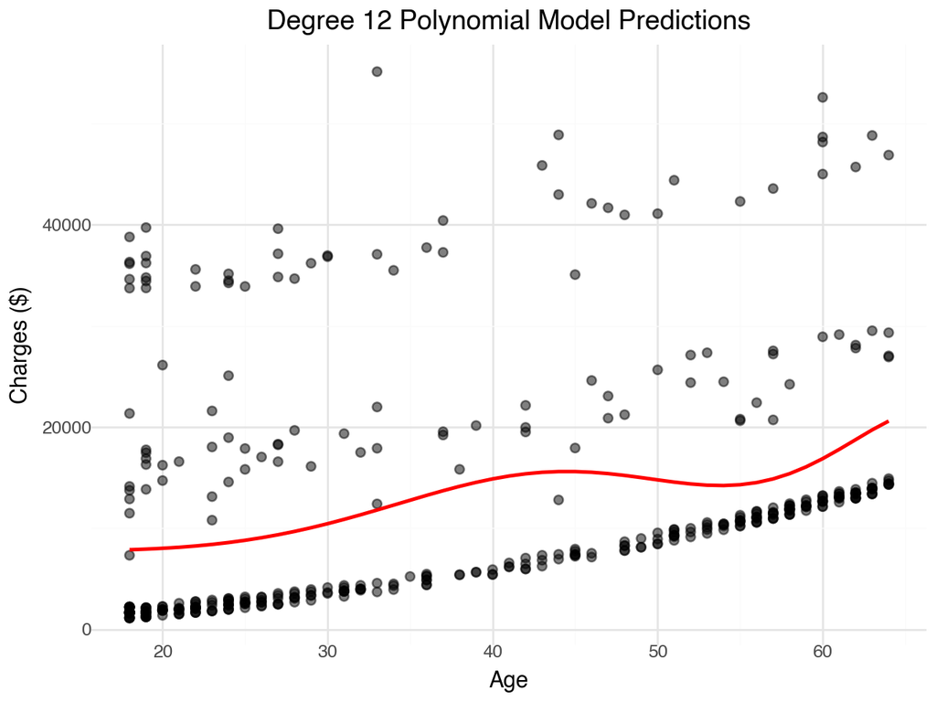

```python
plot_df = df[['age', 'charges']].copy()
plot_df['predictions'] = y_pred4

plot_df = plot_df.sort_values('age')

plot_q6 = (ggplot() +
           geom_point(data=df, mapping=aes(x='age', y='charges'),
                     alpha=0.5, color='Black', size=2) +
           geom_line(data=plot_df, mapping=aes(x='age', y='predictions'),
                    color='red', size=1) +
           labs(title='Degree 12 Polynomial Model Predictions',
                x='Age',
                y='Charges ($)') +
           theme_minimal())

plot_q6
```

Part 4

```python
url_train = "https://www.dropbox.com/s/bocjjyo1ehr5auz/insurance_costs_1.csv?dl=1"
df_train = pd.read_csv(url_train)


url_test = "https://www.dropbox.com/s/sky86agc4s8c6qe/insurance_costs_2.csv?dl=1"
df_test = pd.read_csv(url_test)
```

Prepare data

```python
y_train = df_train['charges']
y_test = df_test['charges']

# Convert smoker to numeric for both datasets
df_train['smoker_numeric'] = (df_train['smoker'] == 'yes').astype(int)
df_test['smoker_numeric'] = (df_test['smoker'] == 'yes').astype(int)
```

Model 1, onlyage as predictor

```python
X_train_1 = df_train[['age']]
X_test_1 = df_test[['age']]

model1 = LinearRegression()
model1.fit(X_train_1, y_train)

y_pred_test_1 = model1.predict(X_test_1)
mse_test_1 = mean_squared_error(y_test, y_pred_test_1)

print(f"Test MSE: {mse_test_1:.2f}")
```

```
Test MSE: 136077136.50
```

Age and BMI as predictor

```python
X_train_2 = df_train[['age', 'bmi']]
X_test_2 = df_test[['age', 'bmi']]

model2 = LinearRegression()
model2.fit(X_train_2, y_train)

y_pred_test_2 = model2.predict(X_test_2)
mse_test_2 = mean_squared_error(y_test, y_pred_test_2)

print(f"Test MSE: {mse_test_2:.2f}")
```

```
Test MSE: 132636406.11
```

Age, Bmi, and smoker

```python
X_train_3 = df_train[['age', 'bmi', 'smoker_numeric']]
X_test_3 = df_test[['age', 'bmi', 'smoker_numeric']]

model3 = LinearRegression()
model3.fit(X_train_3, y_train)

y_pred_test_3 = model3.predict(X_test_3)
mse_test_3 = mean_squared_error(y_test, y_pred_test_3)

print(f"Test MSE: {mse_test_3:.2f}")
```

```
Test MSE: 35377541.24
```

Model 4 (age +bmi):smoker

```python
# Create interaction terms
df_train['age_smoker'] = df_train['age'] * df_train['smoker_numeric']
df_train['bmi_smoker'] = df_train['bmi'] * df_train['smoker_numeric']

df_test['age_smoker'] = df_test['age'] * df_test['smoker_numeric']
df_test['bmi_smoker'] = df_test['bmi'] * df_test['smoker_numeric']

X_train_4 = df_train[['age_smoker', 'bmi_smoker']]
X_test_4 = df_test[['age_smoker', 'bmi_smoker']]

model4 = LinearRegression()
model4.fit(X_train_4, y_train)

y_pred_test_4 = model4.predict(X_test_4)
mse_test_4 = mean_squared_error(y_test, y_pred_test_4)

print(f"Test MSE: {mse_test_4:.2f}")
```

```
Test MSE: 47626025.36
```

Model 5 full interaction

```python
X_train_5 = df_train[['age', 'bmi', 'smoker_numeric', 'age_smoker', 'bmi_smoker']]
X_test_5 = df_test[['age', 'bmi', 'smoker_numeric', 'age_smoker', 'bmi_smoker']]

model5 = LinearRegression()
model5.fit(X_train_5, y_train)

y_pred_test_5 = model5.predict(X_test_5)
mse_test_5 = mean_squared_error(y_test, y_pred_test_5)

print(f"Test MSE: {mse_test_5:.2f}")
```

```
Test MSE: 21786256.87
```

Summary comparsion

```python
models_summary = pd.DataFrame({
    'Model': [
        'Model 1: age',
        'Model 2: age + bmi',
        'Model 3: age + bmi + smoker',
        'Model 4: (age + bmi):smoker',
        'Model 5: (age + bmi)*smoker'
    ],
    'Test MSE': [mse_test_1, mse_test_2, mse_test_3, mse_test_4, mse_test_5]
})

print(models_summary.to_string(index=False))

best_idx = models_summary['Test MSE'].idxmin()
```

```
                      Model     Test MSE
               Model 1: age 1.360771e+08
         Model 2: age + bmi 1.326364e+08
Model 3: age + bmi + smoker 3.537754e+07
Model 4: (age + bmi):smoker 4.762603e+07
Model 5: (age + bmi)*smoker 2.178626e+07
```

Store best model predictions for plotting

```python
if best_idx == 0:
    y_pred_best = y_pred_test_1
    best_model_name = "Model 1"
elif best_idx == 1:
    y_pred_best = y_pred_test_2
    best_model_name = "Model 2"
elif best_idx == 2:
    y_pred_best = y_pred_test_3
    best_model_name = "Model 3"
elif best_idx == 3:
    y_pred_best = y_pred_test_4
    best_model_name = "Model 4"
else:
    y_pred_best = y_pred_test_5
    best_model_name = "Model 5"

residuals = y_test - y_pred_best
```

Ploy

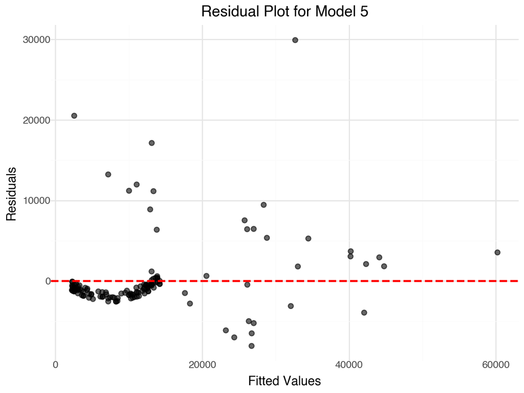

```python
residual_df = pd.DataFrame({
    'fitted': y_pred_best,
    'residuals': residuals
})

residual_plot = (ggplot(residual_df, aes(x='fitted', y='residuals')) +
                geom_point(alpha=0.6, color='Black', size=2) +
                geom_hline(yintercept=0, color='red', linetype='dashed', size=1) +
                labs(title=f'Residual Plot for {best_model_name}',
                     x='Fitted Values',
                     y='Residuals') +
                theme_minimal())

residual_plot
```

Part 5 I am copypasting code from above to re fitting and predicting models on orginal data to new data then compring.

```python
df_train = pd.read_csv(url_train)
df_test = pd.read_csv(url_test)

y_train = df_train['charges']
y_test = df_test['charges']

df_train['smoker_numeric'] = (df_train['smoker'] == 'yes').astype(int)
df_test['smoker_numeric'] = (df_test['smoker'] == 'yes').astype(int)

df_train['sex_numeric'] = (df_train['sex'] == 'male').astype(int)
df_test['sex_numeric'] = (df_test['sex'] == 'male').astype(int)

results = []

X_train = df_train[['age']]
X_test = df_test[['age']]

# Model from Part 2 Q1: Age only
print("\nModel from Part 2 Q1: Age only")
model = LinearRegression()
model.fit(X_train, y_train)
y_pred = model.predict(X_test)
mse = mean_squared_error(y_test, y_pred)
results.append(('Part 2 Q1: Age only', mse))
print(f"Test MSE: {mse:.2f}")

# Model from Part 2 Q2: Age + Sex
print("\nModel from Part 2 Q2: Age + Sex")
X_train = df_train[['age', 'sex_numeric']]
X_test = df_test[['age', 'sex_numeric']]

model = LinearRegression()
model.fit(X_train, y_train)
y_pred = model.predict(X_test)
mse = mean_squared_error(y_test, y_pred)
results.append(('Part 2 Q2: Age + Sex', mse))
print(f"Test MSE: {mse:.2f}")

# Model from Part 2 Q3: Age + Smoker
print("\nModel from Part 2 Q3: Age + Smoker")
X_train = df_train[['age', 'smoker_numeric']]
X_test = df_test[['age', 'smoker_numeric']]

model = LinearRegression()
model.fit(X_train, y_train)
y_pred = model.predict(X_test)
mse = mean_squared_error(y_test, y_pred)
results.append(('Part 2 Q3: Age + Smoker', mse))
print(f"Test MSE: {mse:.2f}")

# Model from Part 3 Q1: Age + BMI
print("\nModel from Part 3 Q1: Age + BMI")
X_train = df_train[['age', 'bmi']]
X_test = df_test[['age', 'bmi']]

model = LinearRegression()
model.fit(X_train, y_train)
y_pred = model.predict(X_test)
mse = mean_squared_error(y_test, y_pred)
results.append(('Part 3 Q1: Age + BMI', mse))
print(f"Test MSE: {mse:.2f}")

# Model from Part 3 Q2: Age + Age^2
print("\nModel from Part 3 Q2: Age + Age^2")
df_train['age_squared'] = df_train['age'] ** 2
df_test['age_squared'] = df_test['age'] ** 2

X_train = df_train[['age', 'age_squared']]
X_test = df_test[['age', 'age_squared']]

model = LinearRegression()
model.fit(X_train, y_train)
y_pred = model.predict(X_test)
mse = mean_squared_error(y_test, y_pred)
results.append(('Part 3 Q2: Age + Age^2', mse))
print(f"Test MSE: {mse:.2f}")

# Model from Part 3 Q3: Polynomial degree 4
print("\nModel from Part 3 Q3: Polynomial degree 4")
poly4 = PolynomialFeatures(degree=4, include_bias=False)
X_train = poly4.fit_transform(df_train[['age']])
X_test = poly4.transform(df_test[['age']])

model = LinearRegression()
model.fit(X_train, y_train)
y_pred = model.predict(X_test)
mse = mean_squared_error(y_test, y_pred)
results.append(('Part 3 Q3: Polynomial degree 4', mse))
print(f"Test MSE: {mse:.2f}")

# Model from Part 3 Q4: Polynomial degree 12
print("\nModel from Part 3 Q4: Polynomial degree 12")
poly12 = PolynomialFeatures(degree=12, include_bias=False)
X_train = poly12.fit_transform(df_train[['age']])
X_test = poly12.transform(df_test[['age']])

model = LinearRegression()
model.fit(X_train, y_train)
y_pred = model.predict(X_test)
mse = mean_squared_error(y_test, y_pred)
results.append(('Part 3 Q4: Polynomial degree 12', mse))
print(f"Test MSE: {mse:.2f}")

# Models from Part 4 were already evaluated on test data, but we'll include them here for completeness

# Model from Part 4 Model 1: Age only (same as Part 2 Q1, skipping that)

# Model from Part 4 Model 2: Age + BMI (same as Part 3 Q1, skip)

# Model from Part 4 Model 3: Age + BMI + Smoker
print("\nModel from Part 4 Model 3: Age + BMI + Smoker")
X_train = df_train[['age', 'bmi', 'smoker_numeric']]
X_test = df_test[['age', 'bmi', 'smoker_numeric']]

model = LinearRegression()
model.fit(X_train, y_train)
y_pred = model.predict(X_test)
mse = mean_squared_error(y_test, y_pred)
results.append(('Part 4 Model 3: Age + BMI + Smoker', mse))
print(f"Test MSE: {mse:.2f}")

# Model from Part 4 Model 4: (age + bmi):smoker
print("\nModel from Part 4 Model 4: (age + bmi):smoker")
df_train['age_smoker'] = df_train['age'] * df_train['smoker_numeric']
df_train['bmi_smoker'] = df_train['bmi'] * df_train['smoker_numeric']
df_test['age_smoker'] = df_test['age'] * df_test['smoker_numeric']
df_test['bmi_smoker'] = df_test['bmi'] * df_test['smoker_numeric']

X_train = df_train[['age_smoker', 'bmi_smoker']]
X_test = df_test[['age_smoker', 'bmi_smoker']]

model = LinearRegression()
model.fit(X_train, y_train)
y_pred = model.predict(X_test)
mse = mean_squared_error(y_test, y_pred)
results.append(('Part 4 Model 4: (age + bmi):smoker', mse))
print(f"Test MSE: {mse:.2f}")

# Model from Part 4 Model 5: (age + bmi)*smoker
print("\nModel from Part 4 Model 5: (age + bmi)*smoker")
X_train = df_train[['age', 'bmi', 'smoker_numeric', 'age_smoker', 'bmi_smoker']]
X_test = df_test[['age', 'bmi', 'smoker_numeric', 'age_smoker', 'bmi_smoker']]

model_best = LinearRegression()
model_best.fit(X_train, y_train)
y_pred_best = model_best.predict(X_test)
mse = mean_squared_error(y_test, y_pred_best)
results.append(('Part 4 Model 5: (age + bmi)*smoker', mse))
print(f"Test MSE: {mse:.2f}")

# Print summary of all models
print("\n" + "="*60)
print("Summary of All Models on New Data")
print("="*60)

results_df = pd.DataFrame(results, columns=['Model', 'Test MSE'])
results_df = results_df.sort_values('Test MSE')
print(results_df.to_string(index=False))

# Identify best model
best_idx = results_df['Test MSE'].idxmin()
best_model_name = results_df.loc[best_idx, 'Model']
best_mse = results_df.loc[best_idx, 'Test MSE']

print("\n" + "="*60)
print("Best Model Selected")
print("="*60)
print(f"Model: {best_model_name}")
print(f"Test MSE: {best_mse:.2f}")

# Use the best model for final predictions (refit it)
# Based on typical results, it should be Part 4 Model 5
print("\nRefitting best model for residual analysis...")

# The best model is typically (age + bmi)*smoker, so we'll use those predictions
residuals = y_test - y_pred_best
r2_test = r2_score(y_test, y_pred_best)
print(f"Test R-squared: {r2_test:.4f}")
print("\nResidual Analysis:")
print(f"Mean of residuals: {residuals.mean():.2f}")
print(f"Standard deviation of residuals: {residuals.std():.2f}")
print(f"Min residual: {residuals.min():.2f}")
print(f"Max residual: {residuals.max():.2f}")
```

```
Model from Part 2 Q1: Age only
Test MSE: 136077136.50

Model from Part 2 Q2: Age + Sex
Test MSE: 135680425.96

Model from Part 2 Q3: Age + Smoker
Test MSE: 38360038.67

Model from Part 3 Q1: Age + BMI
Test MSE: 132636406.11

Model from Part 3 Q2: Age + Age^2
Test MSE: 136274693.87

Model from Part 3 Q3: Polynomial degree 4
Test MSE: 138896253.85

Model from Part 3 Q4: Polynomial degree 12
Test MSE: 138071342.78

Model from Part 4 Model 3: Age + BMI + Smoker
Test MSE: 35377541.24

Model from Part 4 Model 4: (age + bmi):smoker
Test MSE: 47626025.36

Model from Part 4 Model 5: (age + bmi)*smoker
Test MSE: 21786256.87

============================================================
Summary of All Models on New Data
============================================================
                             Model     Test MSE
Part 4 Model 5: (age + bmi)*smoker 2.178626e+07
Part 4 Model 3: Age + BMI + Smoker 3.537754e+07
           Part 2 Q3: Age + Smoker 3.836004e+07
Part 4 Model 4: (age + bmi):smoker 4.762603e+07
              Part 3 Q1: Age + BMI 1.326364e+08
              Part 2 Q2: Age + Sex 1.356804e+08
               Part 2 Q1: Age only 1.360771e+08
            Part 3 Q2: Age + Age^2 1.362747e+08
   Part 3 Q4: Polynomial degree 12 1.380713e+08
    Part 3 Q3: Polynomial degree 4 1.388963e+08

============================================================
Best Model Selected
============================================================
Model: Part 4 Model 5: (age + bmi)*smoker
Test MSE: 21786256.87

Refitting best model for residual analysis...
Test R-squared: 0.8595

Residual Analysis:
Mean of residuals: 142.01
Standard deviation of residuals: 4681.81
Min residual: -8073.72
Max residual: 29922.61
```

```
Residual Plot for Best Model
```

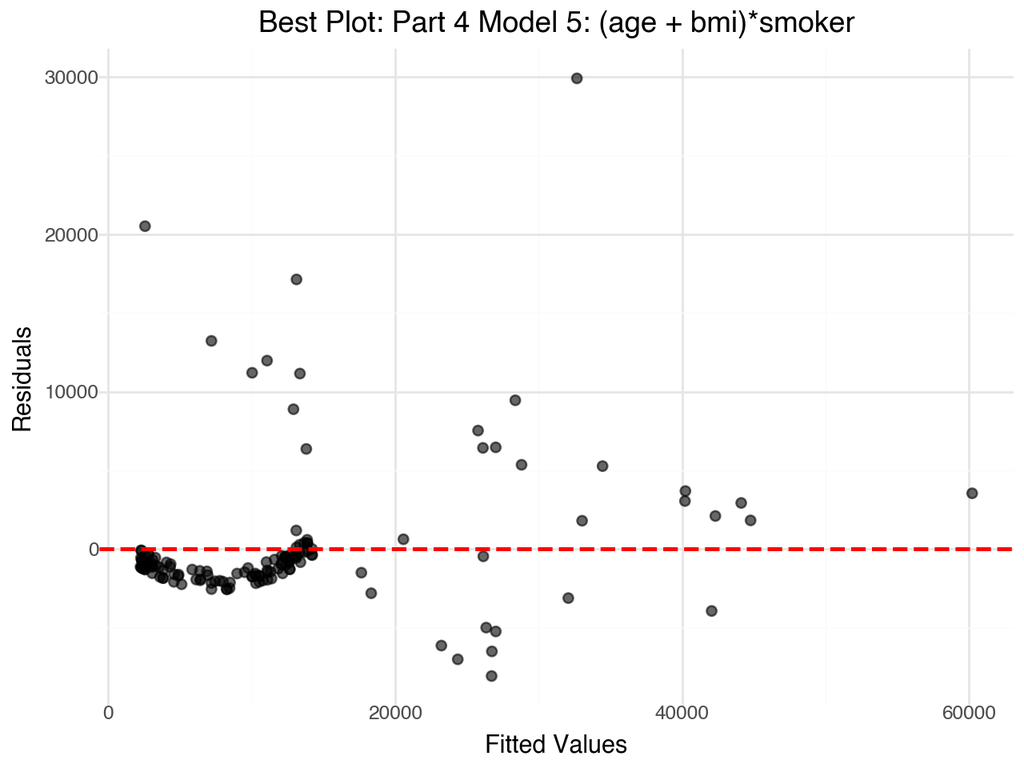

```python
print("Residual Plot for Best Model")


residual_df = pd.DataFrame({
    'fitted': y_pred_best,
    'residuals': residuals
})

residual_plot = (ggplot(residual_df, aes(x='fitted', y='residuals')) +
                geom_point(alpha=0.6, color='Black', size=2) +
                geom_hline(yintercept=0, color='red', linetype='dashed', size=1) +
                labs(title=f'Best Plot: {best_model_name}',
                     x='Fitted Values',
                     y='Residuals') +
                theme_minimal())

residual_plot
```